# Communicate data findings from Prosper Loan Data by `Vital Hakizimana`

## Investigation Overview

In this investigation, I wanted to look at the features that could be used to predict if people will get loan or not according to the relationship between those features with the laon status. The main focus was on 17 features selected: 'Term','LoanStatus','BorrowerAPR','BorrowerRate','BorrowerState','Occupation','EmploymentStatus','EmploymentStatusDuration','IsBorrowerHomeowner','TotalInquiries','AvailableBankcardCredit','TotalTrades','IncomeRange','StatedMonthlyIncome','LoanOriginalAmount','MonthlyLoanPayment','Recommendations'

## Dataset Overview

The data set consisted of 113,937 loans obeservations and 81 features during the starting. I selected the 17 best important features that are sensitive to the loan status and dropped all the missing values in the data set. Then I remained with 103244 loans observations and 17 features.

# Loan status variations

The graph intend to show us the most loan status where many people are in so that we get and idea of which loan status is best fit with many people. From the graph, we will see that the most loan statuses are (current, completed, chargedoff,Defaulted and pastDue(1-15days). Therefore, other loan statuses have very small percentages compared to those ones

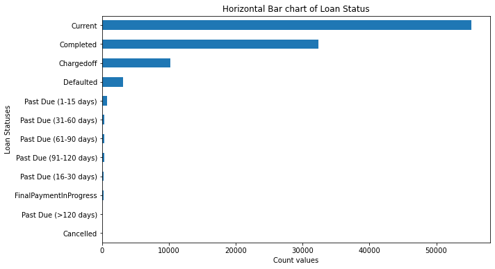

# Distribution of StatedMonthlyIncome

StatedMonthlyIncome in the dataset take on a very large range of values, from about 0 at the lowest, to about 1,750,002 at the highest. Plotted on a logarithmic scale, the distribution of monthly income takes on a multimodal shape.

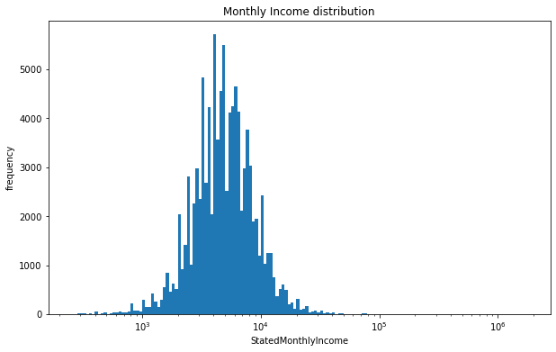

# BorrowerAPR vs BorrowerRate

Therefore, we can see that there is a very strong positive correlation between BorrowerAPR and BorrowerRate. This means that the increase of one variable led to the increase in other variable.

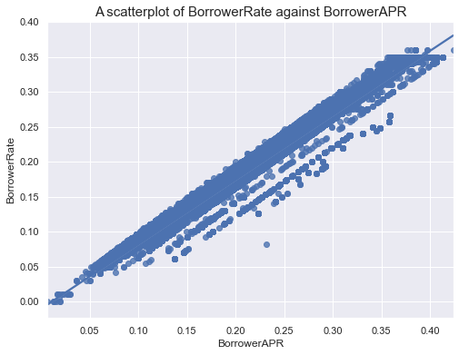

# MonthlyLoanPayment vs LoanOriginalAmount

Therefore, fromt this graph also, we can see that there is a good positive correlation between LoanOriginalAmount and MonthlyLoanPayment. This means that the increase of one variable led to the increase in other variable. Therefore, by having large amount of loan, the client should expect to pay large amount of monthly loan payment

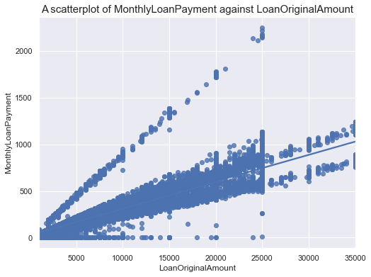

# LoanStatus vs IncomeRange

The bar graph here help us to analyse each loan status with their corresponding IncomeRange. For instance, can observe that for each category of loan status, we have more people from `25,000-49,999 and 50,000-74,999` income ranges.

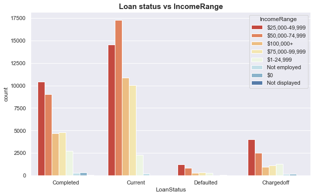

# LoanStatus vs BorrowerState

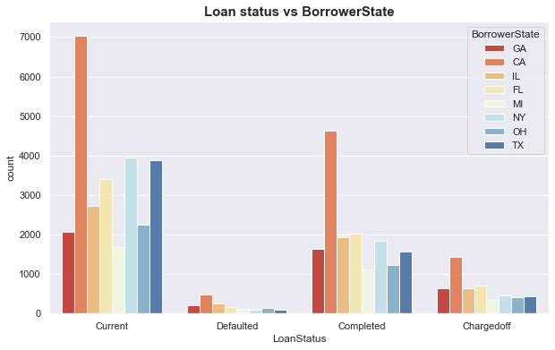

# Relationship between LoanStatus, Term and EmployementStatus

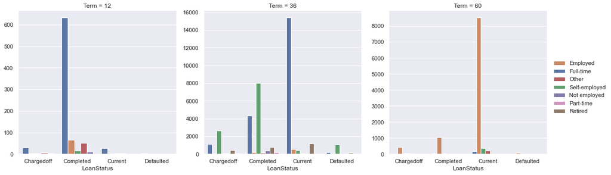